# Exploration of WA DOH School Exemption Data over 3 School Years by Andrew T. Bauman

# Introduction

The initial data and cleaning/assembly of the combined data frame can be found here: [githubrepo](https://github.com/baumanab/EDA_R_Udacity/tree/master/EDA_R_FinalProject/EDA_R_FinalProject.Rmd)

Additional cleaning and wrangling can be found here: [githubrepo](https://github.com/baumanab/EDA_R_Udacity/blob/master/EDA_R_FinalProject/EDA_R_FinalProject_WADOH_DataFrameWrangle.Rmd)

An initial exploration and some additional corrections for student enrollment, is here: [githubrepo](https://github.com/baumanab/EDA_R_Udacity/blob/master/EDA_R_FinalProject/WADOH_DataExplore.Rmd)

The current state is a rough approach and far from perfect. I plan to revisit this as I discover additional elements that need cleaning. I am currently working on a more readable and organized version of the data wrangling using piping, so that changes are easy to make and push to the .rds file called as data for this project.

There are some aspects of vaccination and the spread of disease through populations that are best left to subject matter experts. I consulted CDC publications throughout this analysis and I encourage the reader to do the same.

For example, what is the vaccinatation rate threshold that should not be exceeded to maintain herd immunity? This is complex question. A typical answer is 10%. There are assumptions made regarding mixing of populations and how fast a contagion spreads. This is even more complex in the context of school data where there is a wide range of populations and students may come from a large geographical area. The latter is particularly true of private schools where students may not necessarily live within a specific geographical region.

In regards to spread of disease, some disease are more contagios than others and have a range of opportunities for exposure. For example, while Hep B is fairly contagious (~ 100 X times HIV), since it is blood-borne, the opportunity for exposure is less than something like the common cold. Measles is particularly contagious with a high exposure opportunity and inforomation available from the CDC suggest that vaccination rates <= 95% pose a risk. Bear is mind that this is factoring in that not all those vaccinated will actually be immune, so even at 100% exemption rate, 100% immunity would not be expected.

For the purposes of this analysis, I set the outbreak risk thresholds at 90% for general vaccination rates and 95% for MMR. That translates to 5% exempt for MMR and 10% exempt general.

## Alter Data

# Univariate Plots Section

## Distribution of enrolled students

```
##  [1] "school_year"            "school_code"
##  [3] "school_name"            "school_type"
##  [5] "school_city"            "school_state"
##  [7] "school_zip"             "school_county"
##  [9] "school_district"        "district_code"
## [11] "enrolled"               "total_exemptions"
## [13] "medical_exempt"         "nonmedical_exempt"
## [15] "exempt_MMR"             "percent_exempt"
## [17] "percent_medical_exempt" "percent_nonmedexempt"
## [19] "percent_exempt_MMR"
```

```
## 'data.frame':    6696 obs. of  19 variables:
##  $ school_year           : Factor w/ 3 levels "2011","2012",..: 2 2 2 2 2 2 3 3 3 3 ...
##  $ school_code           : chr  "3706" "2308" "2131" "2757" ...
##  $ school_name           : chr  "Rose Hill Junior High" "Kirkland Junior High" "Wapato Middle School" "Satus Elementary" ...
##  $ school_type           : Factor w/ 2 levels "not_Public","Public": 2 2 2 2 2 2 2 2 2 2 ...
##  $ school_city           : chr  "Redmond" "Kirkland" "Wapato" "Wapato" ...
##  $ school_state          : chr  "WA" "WA" "WA" "WA" ...
##  $ school_zip            : chr  "98052" "98033" "98951" "98951" ...
##  $ school_county         : chr  "KING" "KING" "YAKIMA" "YAKIMA" ...
##  $ school_district       : chr  "Lake Washington School District" "Lake Washington School District" "Wapato School District" "Wapato School District" ...
##  $ district_code         : num  17414 17414 39207 39207 39207 ...
##  $ enrolled              : num  5076 4157 3540 3540 3540 ...
##  $ total_exemptions      : int  121 171 8 8 8 8 7 7 7 7 ...
##  $ medical_exempt        : num  15 13 5 5 5 5 5 5 5 5 ...
##  $ nonmedical_exempt     : num  106 161 3 3 3 3 2 2 2 2 ...
##  $ exempt_MMR            : int  73 101 8 8 8 8 7 7 7 7 ...
##  $ percent_exempt        : num  2.38 4.11 0.23 0.23 0.23 0.23 0.2 0.2 0.2 0.2 ...
##  $ percent_medical_exempt: num  0.296 0.313 0.141 0.141 0.141 ...
##  $ percent_nonmedexempt  : num  2.0883 3.873 0.0847 0.0847 0.0847 ...
##  $ percent_exempt_MMR    : num  1.44 2.43 0.23 0.23 0.23 0.23 0.2 0.2 0.2 0.2 ...
```

```
##  school_year school_code        school_name            school_type
##  2011:1934   Length:6696        Length:6696        not_Public: 968
##  2012:2428   Class :character   Class :character   Public    :5728
##  2013:2334   Mode  :character   Mode  :character
##
##
##
##  school_city        school_state        school_zip
##  Length:6696        Length:6696        Length:6696
##  Class :character   Class :character   Class :character
##  Mode  :character   Mode  :character   Mode  :character
##
##
##
##  school_county      school_district    district_code      enrolled
##  Length:6696        Length:6696        Min.   : 1109   Min.   :   1
##  Class :character   Class :character   1st Qu.:17001   1st Qu.: 212
##  Mode  :character   Mode  :character   Median :20400   Median : 425
##                                        Mean   :22236   Mean   : 474
##                                        3rd Qu.:31016   3rd Qu.: 585
##                                        Max.   :39209   Max.   :5076
##  total_exemptions medical_exempt    nonmedical_exempt   exempt_MMR
##  Min.   :  0.0    Min.   :  0.000   Min.   :  0.00    Min.   :  0.0
##  1st Qu.:  7.0    1st Qu.:  0.000   1st Qu.:  6.00    1st Qu.:  4.0
##  Median : 19.0    Median :  2.000   Median : 17.00    Median : 11.0
##  Mean   : 25.5    Mean   :  3.534   Mean   : 22.28    Mean   : 14.8
##  3rd Qu.: 35.0    3rd Qu.:  4.000   3rd Qu.: 31.00    3rd Qu.: 20.0
##  Max.   :436.0    Max.   :214.000   Max.   :330.00    Max.   :269.0
##  percent_exempt   percent_medical_exempt percent_nonmedexempt
##  Min.   :  0.00   Min.   : 0.0000        Min.   :  0.000
##  1st Qu.:  2.81   1st Qu.: 0.0000        1st Qu.:  2.373
##  Median :  5.01   Median : 0.3883        Median :  4.357
##  Mean   :  6.67   Mean   : 0.7957        Mean   :  5.977
##  3rd Qu.:  7.97   3rd Qu.: 0.9009        3rd Qu.:  7.112
##  Max.   :100.00   Max.   :33.3333        Max.   :100.000
##  percent_exempt_MMR
##  Min.   :  0.000
##  1st Qu.:  1.470
##  Median :  2.840
##  Mean   :  4.208
##  3rd Qu.:  4.680
##  Max.   :100.000
```

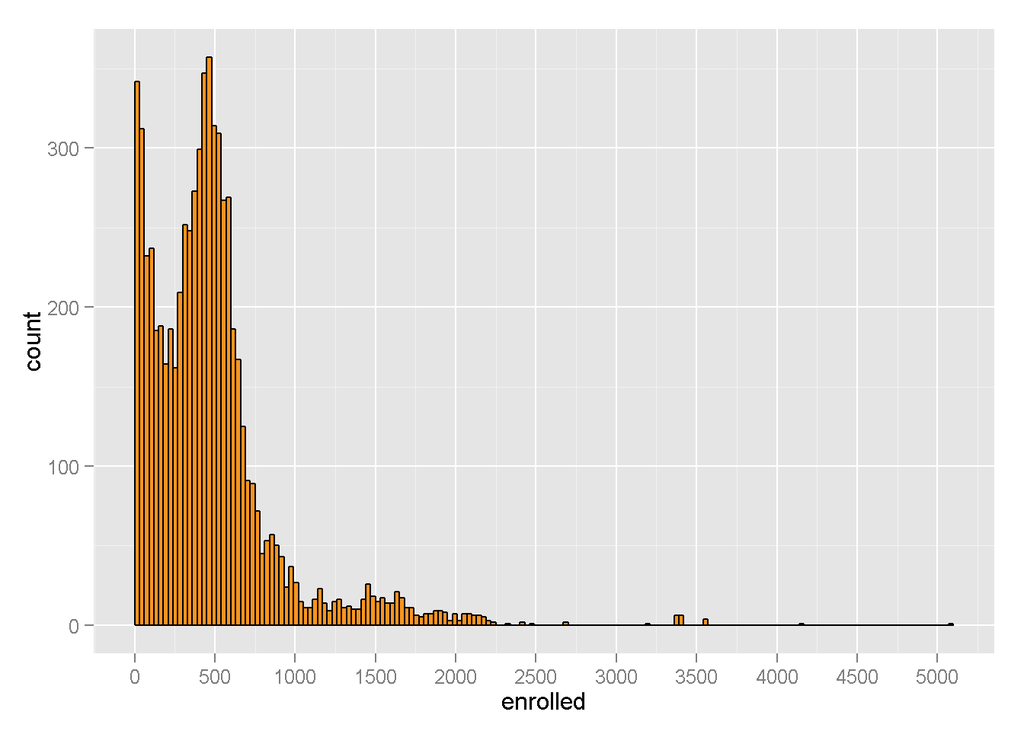

This is a long tailed distribution, a feature exhibited by most distributions in this data set. Log transformations are performed to visualize the data.

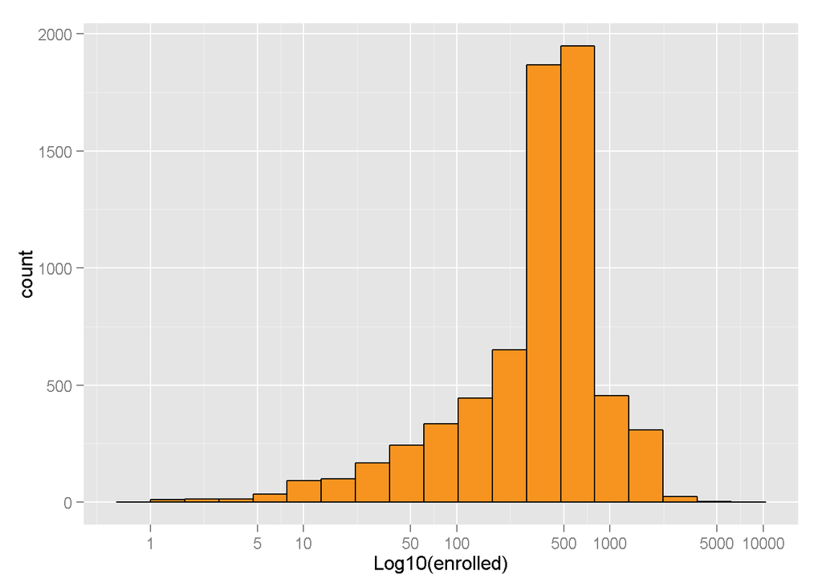

- Range: 1 - 5076*
- Most of the data falls between ~ 100 - 1000 students per school*

## Distribution of total exemptions

```
##    Min. 1st Qu.  Median    Mean 3rd Qu.    Max.
##     0.0     7.0    19.0    25.5    35.0   436.0
```

```
## vaccReported$school_year: 2011
##    Min. 1st Qu.  Median    Mean 3rd Qu.    Max.
##    0.00   10.00   23.00   28.71   38.00  436.00
## --------------------------------------------------------
## vaccReported$school_year: 2012
##    Min. 1st Qu.  Median    Mean 3rd Qu.    Max.
##    0.00    6.00   18.00   23.84   33.00  371.00
## --------------------------------------------------------
## vaccReported$school_year: 2013
##    Min. 1st Qu.  Median    Mean 3rd Qu.    Max.
##    0.00    7.00   18.00   24.56   33.00  357.00
```

```
##    Min. 1st Qu.  Median    Mean 3rd Qu.    Max.
##    0.00    2.81    5.01    6.67    7.97  100.00
```

```
## vaccReported$school_year: 2011
##    Min. 1st Qu.  Median    Mean 3rd Qu.    Max.
##   0.000   3.182   5.320   6.761   8.198  60.000
## --------------------------------------------------------
## vaccReported$school_year: 2012
##    Min. 1st Qu.  Median    Mean 3rd Qu.    Max.
##   0.000   2.690   4.855   6.642   7.912 100.000
## --------------------------------------------------------
## vaccReported$school_year: 2013
##    Min. 1st Qu.  Median    Mean 3rd Qu.    Max.
##   0.000   2.700   4.875   6.623   7.920 100.000
```

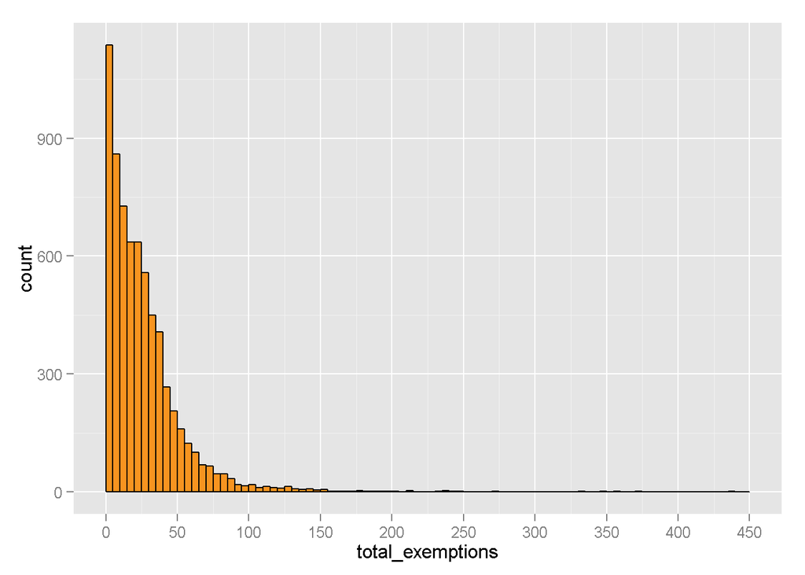

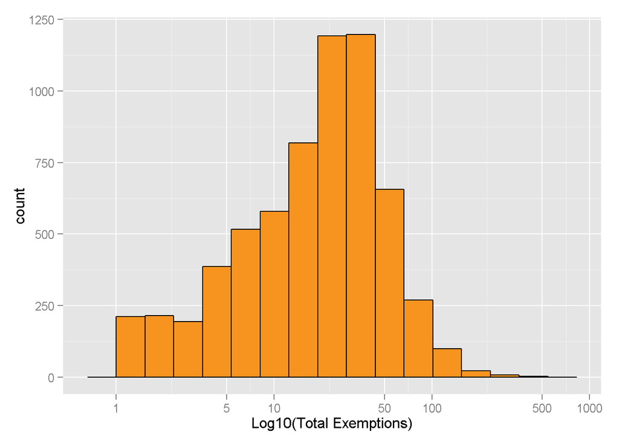

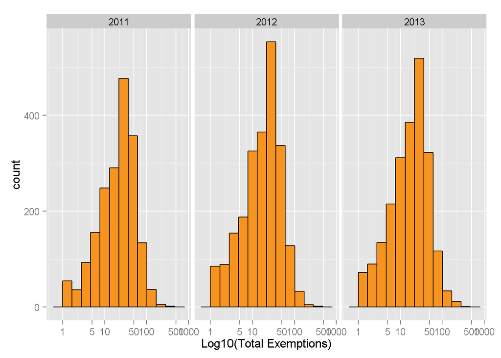

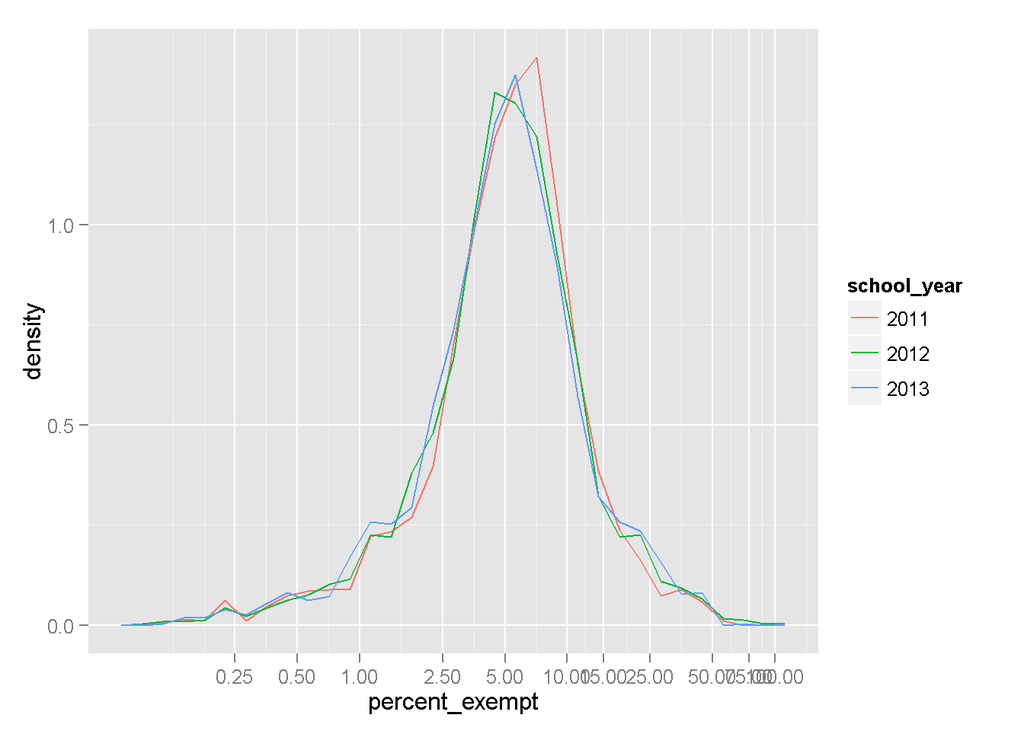

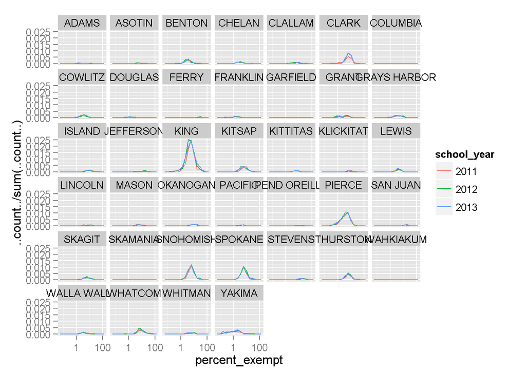

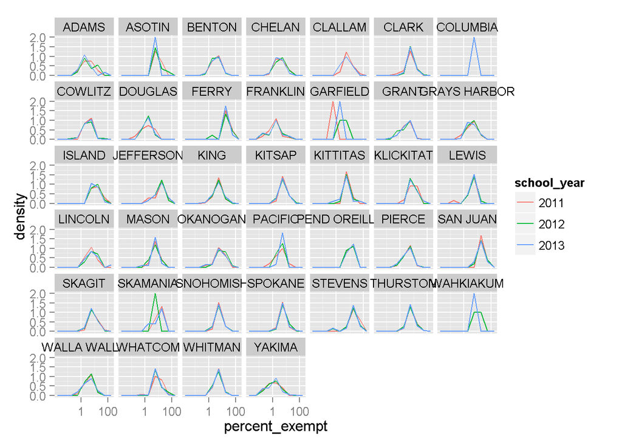

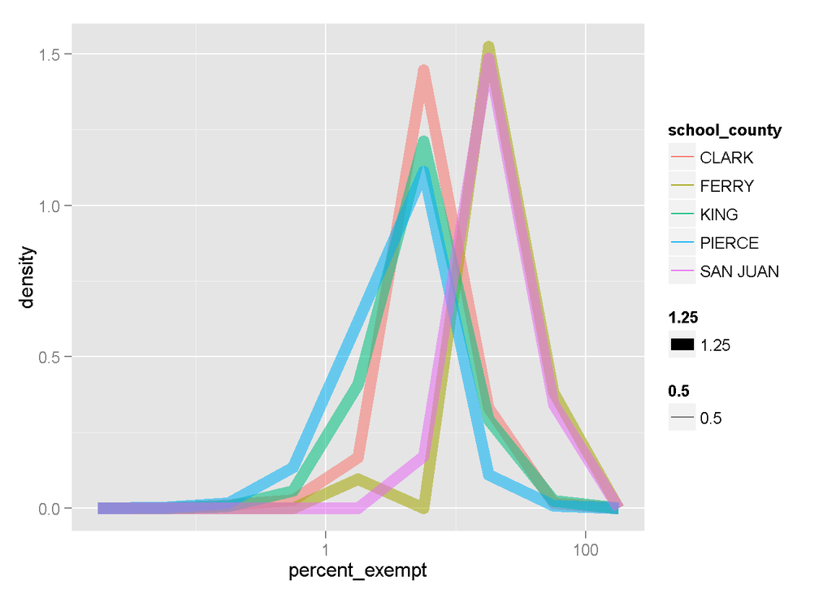

- Range: 0 - 436*
- Rate: 0 - 100%, ~ 6.6% mean for all 3 school years*
- The highest density data is from ~ 10 - 75 students per school*
- Year to year distributions are similiar for total and rate*
- most schools fall into a rate range of 2-25%*
- King County has the highest proportion of exemptions*
- There appears to be some smaller counties (i.e. Ferry, San Juan) and others with more density at higher exemption rates than King and Pierce county (most populous counties in WA)*

**Note:** Higher exemption rates of ~ > 50% appear to be associated with lower levels of enrollment (< 100 students). This will be investigated in the bivariate section.

## Medical Exemptions

```
##    Min. 1st Qu.  Median    Mean 3rd Qu.    Max.
##   0.000   0.000   2.000   3.534   4.000 214.000
```

```
## vaccReported$school_year: 2011
##    Min. 1st Qu.  Median    Mean 3rd Qu.    Max.
##   0.000   0.000   1.000   2.937   3.000 168.000
## --------------------------------------------------------
## vaccReported$school_year: 2012
##    Min. 1st Qu.  Median    Mean 3rd Qu.    Max.
##   0.000   0.000   2.000   3.014   4.000 186.000
## --------------------------------------------------------
## vaccReported$school_year: 2013
##    Min. 1st Qu.  Median    Mean 3rd Qu.    Max.
##   0.000   0.000   2.000   4.569   5.000 214.000
```

```
##    Min. 1st Qu.  Median    Mean 3rd Qu.    Max.
##  0.0000  0.0000  0.3883  0.7957  0.9009 33.3300
```

```
## vaccReported$school_year: 2011
##    Min. 1st Qu.  Median    Mean 3rd Qu.    Max.
##  0.0000  0.0000  0.3140  0.5583  0.6891 17.6800
## --------------------------------------------------------
## vaccReported$school_year: 2012
##    Min. 1st Qu.  Median    Mean 3rd Qu.    Max.
##  0.0000  0.0000  0.3711  0.7112  0.8777 33.3300
## --------------------------------------------------------
## vaccReported$school_year: 2013
##    Min. 1st Qu.  Median    Mean 3rd Qu.    Max.
##  0.0000  0.0000  0.5128  1.0800  1.0980 29.6300
```

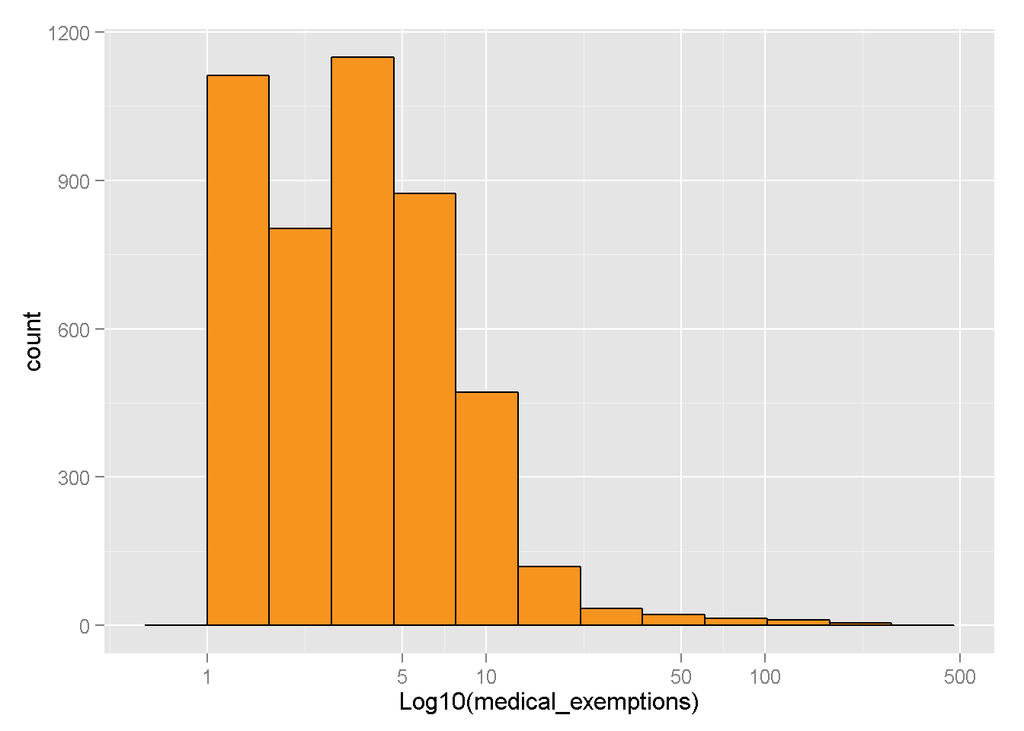

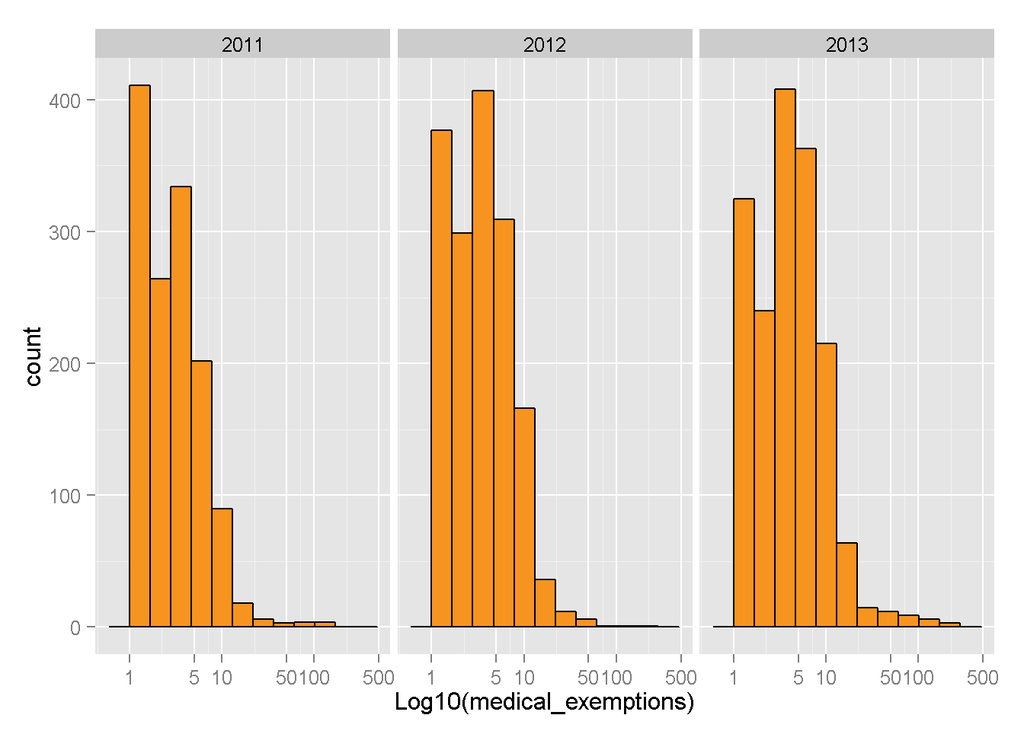

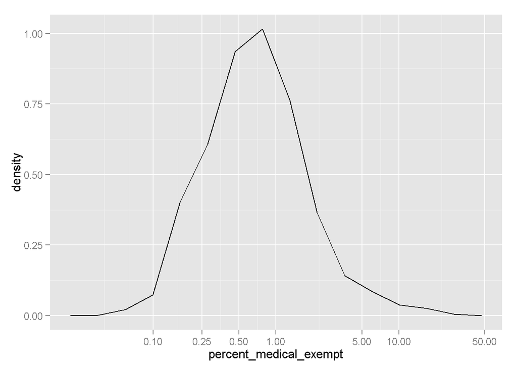

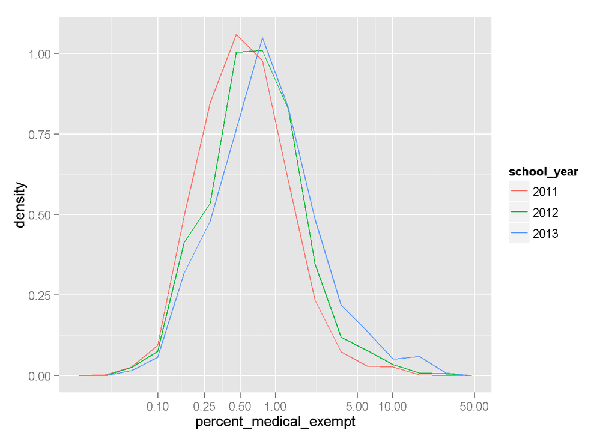

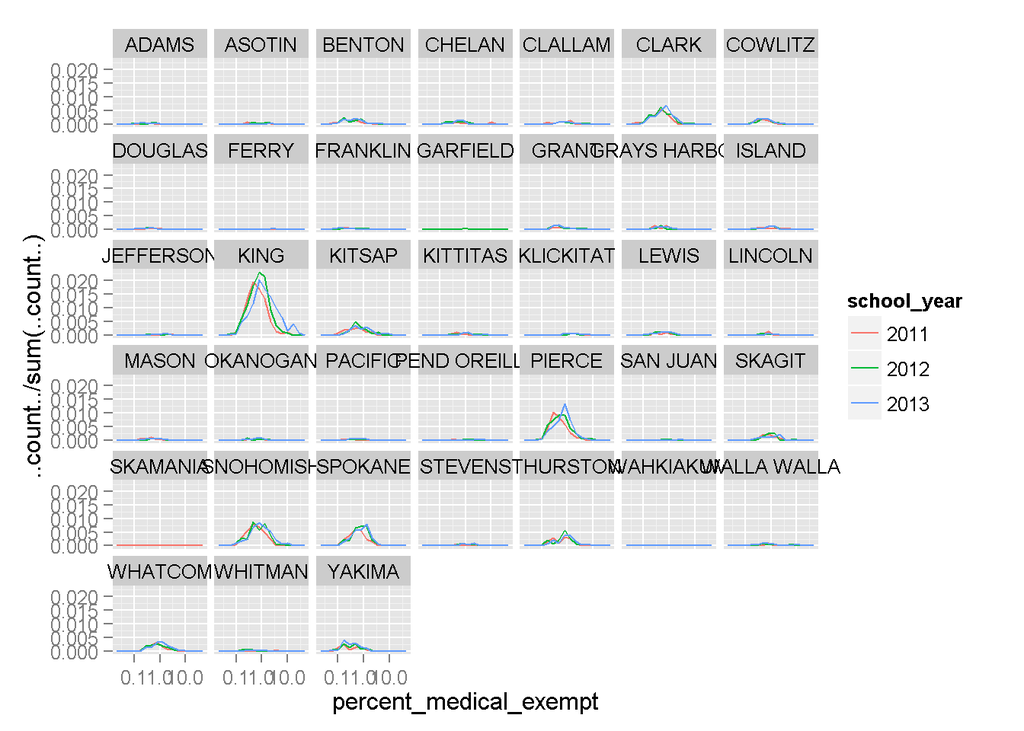

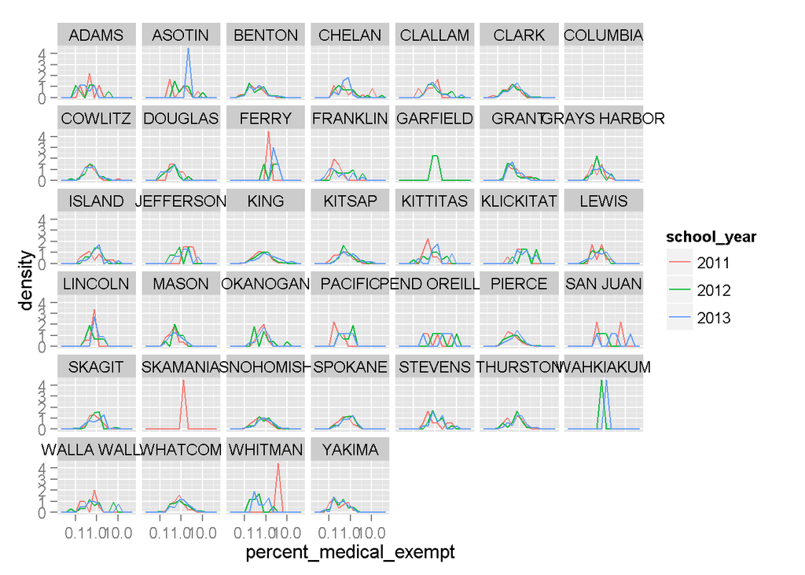

- Range of 0-214 exemptions*
- Substantial rate increase from 2012 -> 2013*
- Most schools have 1-10 students with medical exemptions*
- The rate range is ` 0 -33% with most schols falling between ~0.1 and 5%*
- The mean rate rose from .55% to 1.08% from 2011 -> 2013*
- Overall distribution of rate shifts towards higher rates from 2011 -> 2013*
- King County*
- highest proportion*
- substantial shift to higer rates from 2011 -> 2013*
- there is a distinct spike at > 10%*
- Columbia county has not reported any medical exemptions for any year*

## Non-medical Exemptions

```
##    Min. 1st Qu.  Median    Mean 3rd Qu.    Max.
##    0.00    6.00   17.00   22.28   31.00  330.00
```

```
## vaccReported$school_year: 2011
##    Min. 1st Qu.  Median    Mean 3rd Qu.    Max.
##    0.00    9.00   20.00   25.77   35.00  327.00
## --------------------------------------------------------
## vaccReported$school_year: 2012
##    Min. 1st Qu.  Median    Mean 3rd Qu.    Max.
##    0.00    5.00   15.00   21.18   29.00  330.00
## --------------------------------------------------------
## vaccReported$school_year: 2013
##    Min. 1st Qu.  Median    Mean 3rd Qu.    Max.
##    0.00    6.00   15.00   20.55   28.00  313.00
```

```
##    Min. 1st Qu.  Median    Mean 3rd Qu.    Max.
##   0.000   2.373   4.357   5.977   7.112 100.000
```

```
## vaccReported$school_year: 2011
##    Min. 1st Qu.  Median    Mean 3rd Qu.    Max.
##   0.000   2.828   4.785   6.202   7.524  60.000
## --------------------------------------------------------
## vaccReported$school_year: 2012
##    Min. 1st Qu.  Median    Mean 3rd Qu.    Max.
##   0.000   2.272   4.324   6.080   7.147 100.000
## --------------------------------------------------------
## vaccReported$school_year: 2013
##    Min. 1st Qu.  Median    Mean 3rd Qu.    Max.
##   0.000   2.212   4.037   5.684   6.629 100.000
```

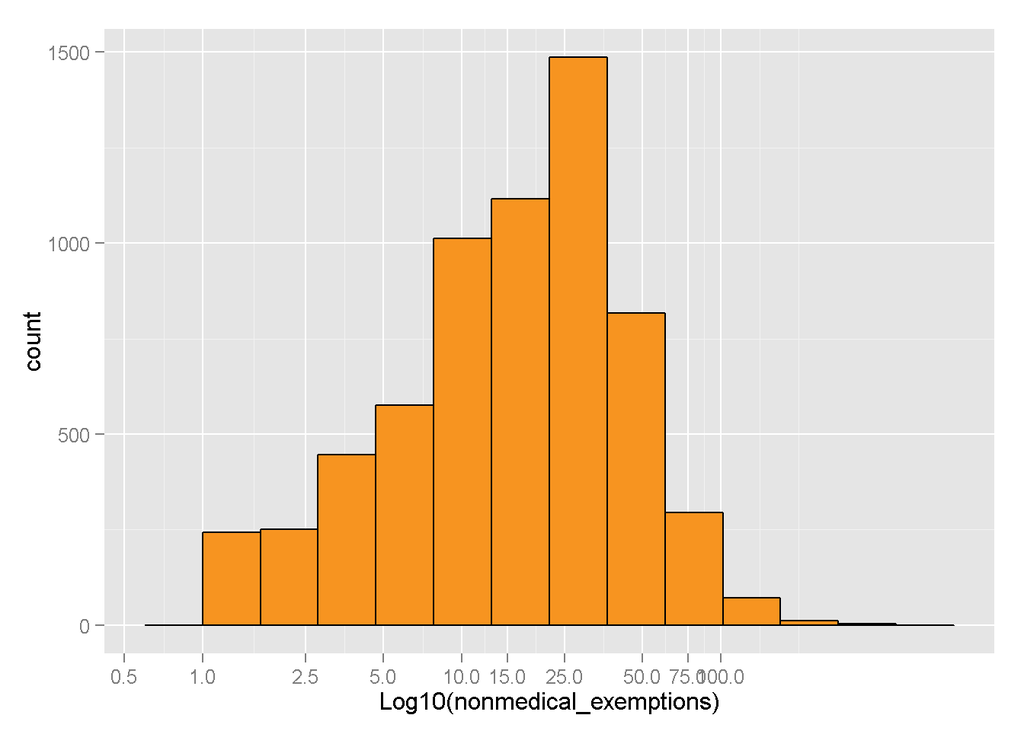

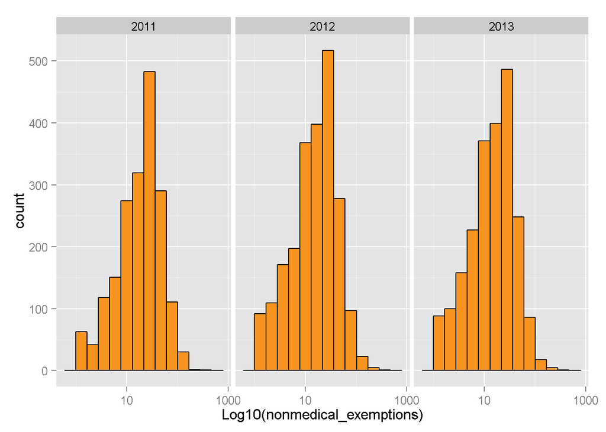

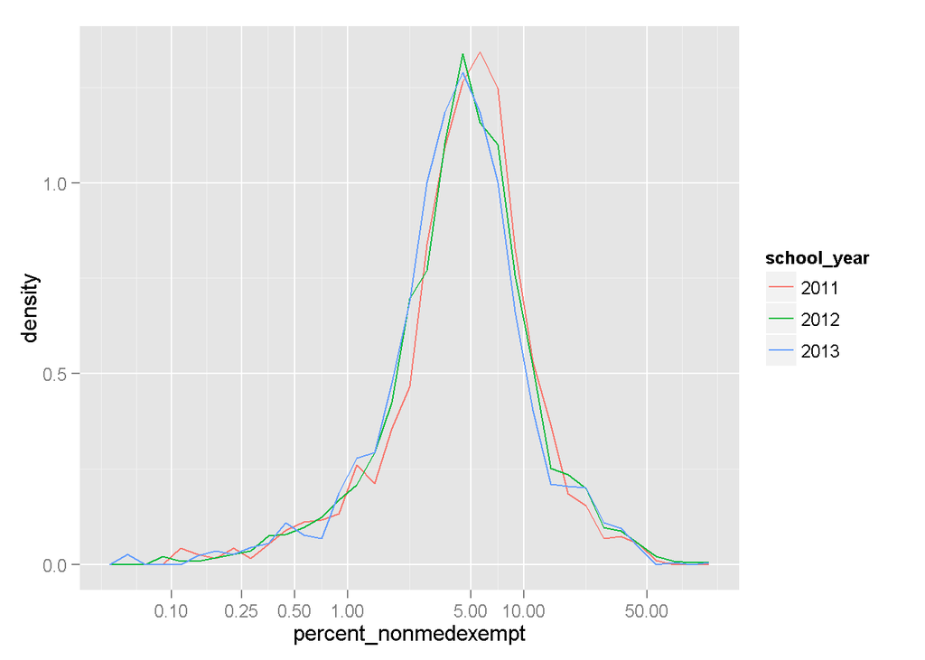

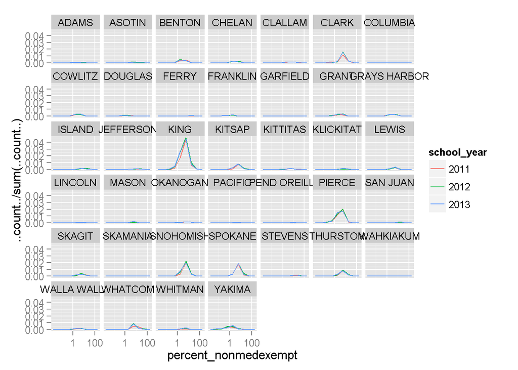

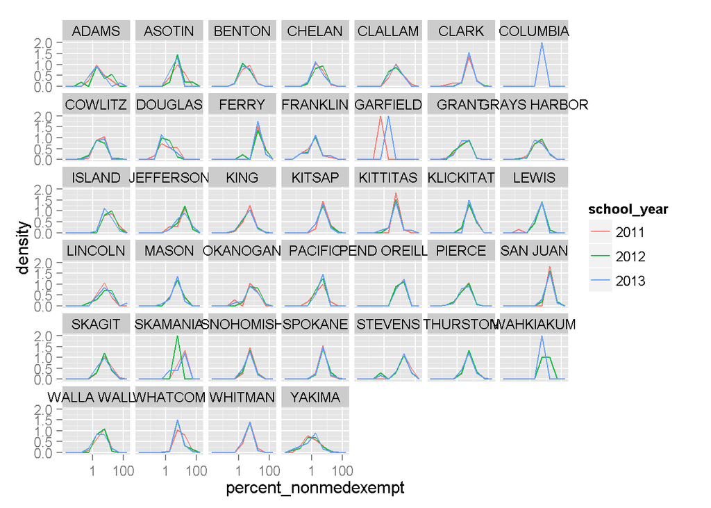

- Range 0 - 330 with most schools haveing ~8-75 nonmedical exempt students*
- Mean fell by ~ 5 students per school 2011 -> 2013*
- Rate of 0 -100% with most schools at ~ 1 - 20% nonmedical exempt*
- No substantial change in mean rate (~6%) from 2011 -> 2013*
- King County has the largest proportion of nonmedical exempt*
- Ferry and San Juan counties distributiion is at a higher % than King County*

## MMR Exemptions

```
##    Min. 1st Qu.  Median    Mean 3rd Qu.    Max.
##     0.0     4.0    11.0    14.8    20.0   269.0
```

```
## vaccReported$school_year: 2011
##    Min. 1st Qu.  Median    Mean 3rd Qu.    Max.
##    0.00    5.00   12.00   15.29   21.00  229.00
## --------------------------------------------------------
## vaccReported$school_year: 2012
##    Min. 1st Qu.  Median    Mean 3rd Qu.    Max.
##    0.00    4.00   11.00   14.58   20.00  267.00
## --------------------------------------------------------
## vaccReported$school_year: 2013
##    Min. 1st Qu.  Median    Mean 3rd Qu.    Max.
##    0.00    4.00   11.00   14.63   20.00  269.00
```

```
##    Min. 1st Qu.  Median    Mean 3rd Qu.    Max.
##   0.000   1.470   2.840   4.208   4.680 100.000
```

```
## vaccReported$school_year: 2011
##    Min. 1st Qu.  Median    Mean 3rd Qu.    Max.
##   0.000   1.440   2.720   3.840   4.547  54.950
## --------------------------------------------------------
## vaccReported$school_year: 2012
##    Min. 1st Qu.  Median    Mean 3rd Qu.    Max.
##   0.000   1.518   2.920   4.509   4.812 100.000
## --------------------------------------------------------
## vaccReported$school_year: 2013
##    Min. 1st Qu.  Median    Mean 3rd Qu.    Max.
##   0.000   1.480   2.845   4.200   4.640 100.000
```

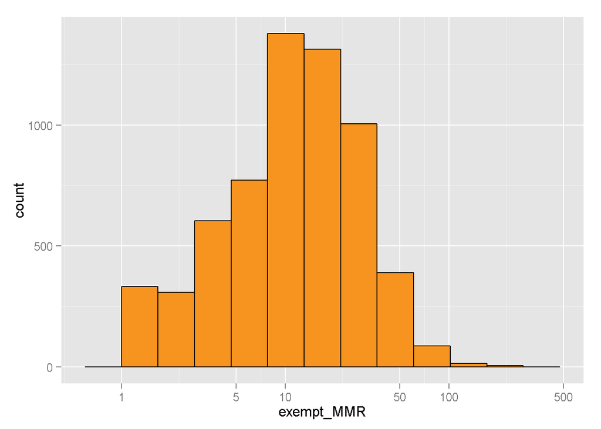

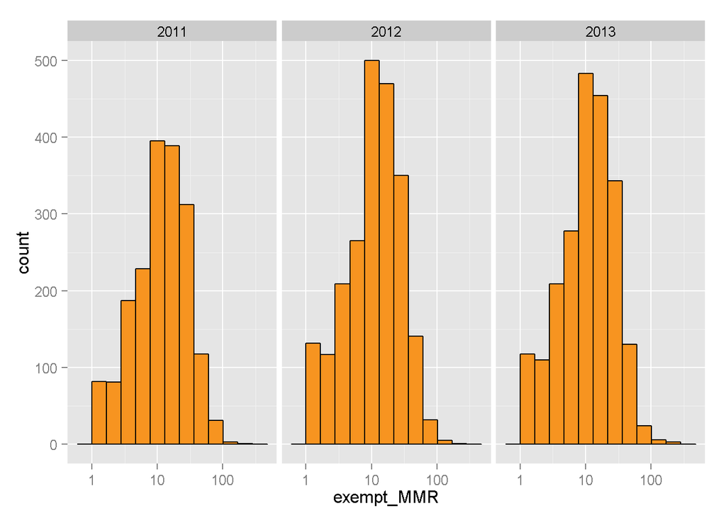

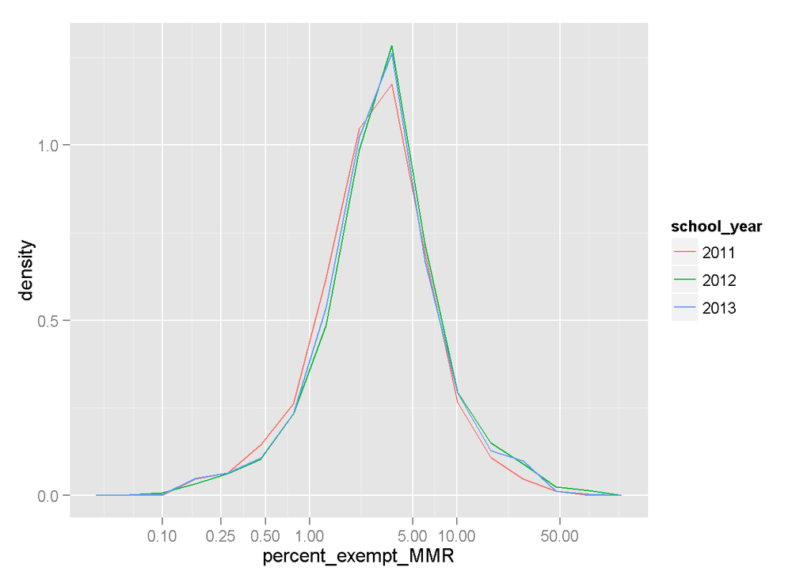

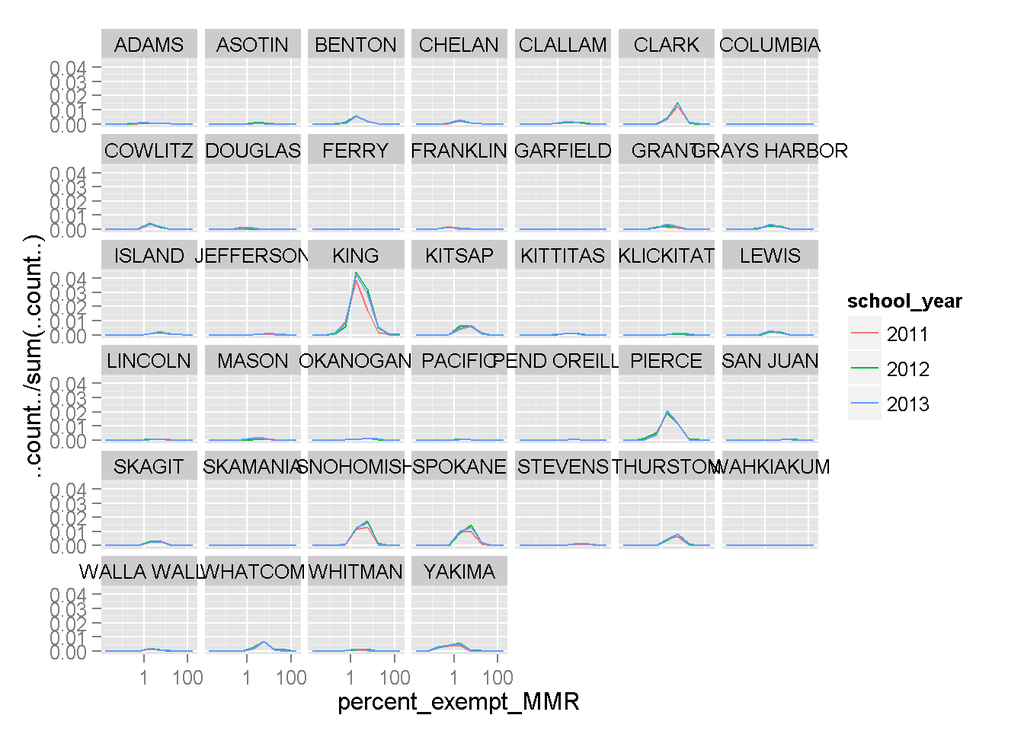

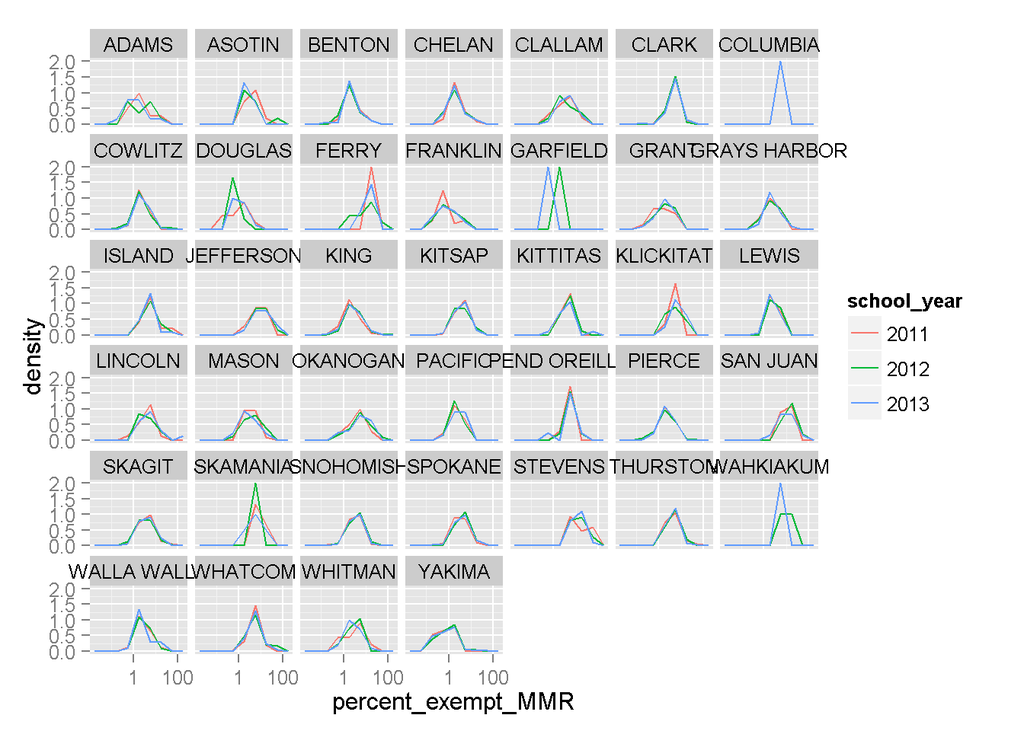

[figure not shown]

- Range 0-269 with most schools haveing 3 - 40 MMR exempt students*
- Rate 0 -100% with most schools falling between ~0.5 - 20%*
- No substntial change in total mean or mean rate from 2011 -> 2013*
- King County has the largest proportion of nonmedical exempt*
- Ferry and San Juan counties distributiion is at a higher % than King County*

## Explore Exemption Types

Gather terms for exemption type (melt) the dataframe, the calculate the % of total exemptions that are of a particular type (medical or non-medical) While this is not a tidy data frame it is a convenient way to look at observations by exemption type. I am using this to develop a better understanding of the propotion of exemptions that are non-medical.

```
## 'data.frame':    13160 obs. of  19 variables:
##  $ school_year           : Factor w/ 3 levels "2011","2012",..: 2 2 2 3 2 2 1 2 1 2 ...
##  $ school_code           : chr  "1456" "800R" "3808" "3808" ...
##  $ school_name           : chr  "Tacoma Waldorf School" "Rising Tide School" "Waldron Island School" "Waldron Island School" ...
##  $ school_type           : Factor w/ 2 levels "not_Public","Public": 1 1 2 2 2 2 2 1 1 1 ...
##  $ school_city           : chr  "Tacoma" "Olympia" "WALDRON ISLAND" "Waldron Island" ...
##  $ school_state          : chr  "WA" "WA" "WA" "WA" ...
##  $ school_zip            : chr  "98405" "98501" "98297" "98297" ...
##  $ school_county         : chr  "PIERCE" "THURSTON" "SAN JUAN" "SAN JUAN" ...
##  $ school_district       : chr  "Tacoma School District" "Olympia School District" "Orcas Island School District" "Orcas Island School District" ...
##  $ district_code         : num  27010 34111 28137 28137 2250 ...
##  $ enrolled              : num  24 14 12 14 10 82 25 100 91 22 ...
##  $ total_exemptions      : int  20 11 9 10 7 50 15 55 50 12 ...
##  $ exempt_MMR            : int  20 11 8 9 7 27 11 55 50 8 ...
##  $ percent_exempt        : num  83.3 78.6 75 71.4 70 ...
##  $ percent_medical_exempt: num  0 0 0 0 10 ...
##  $ percent_nonmedexempt  : num  91.7 78.6 75 71.4 60 ...
##  $ percent_exempt_MMR    : num  83.3 78.6 66.7 64.3 70 ...
##  $ exemption_type        : Factor w/ 2 levels "medical_exempt",..: 1 1 1 1 1 1 1 1 1 1 ...
##  $ exemptions            : num  0 0 0 0 1 2 0 0 0 0 ...
```

```
##  [1] "school_year"            "school_code"
##  [3] "school_name"            "school_type"
##  [5] "school_city"            "school_state"
##  [7] "school_zip"             "school_county"
##  [9] "school_district"        "district_code"
## [11] "enrolled"               "total_exemptions"
## [13] "exempt_MMR"             "percent_exempt"
## [15] "percent_medical_exempt" "percent_nonmedexempt"
## [17] "percent_exempt_MMR"     "exemption_type"
## [19] "exemptions"
```

```
##  school_year school_code        school_name            school_type
##  2011:3834   Length:13160       Length:13160       not_Public: 1822
##  2012:4740   Class :character   Class :character   Public    :11338
##  2013:4586   Mode  :character   Mode  :character
##
##
##
##  school_city        school_state        school_zip
##  Length:13160       Length:13160       Length:13160
##  Class :character   Class :character   Class :character
##  Mode  :character   Mode  :character   Mode  :character
##
##
##
##  school_county      school_district    district_code      enrolled
##  Length:13160       Length:13160       Min.   : 1109   Min.   :  10.0
##  Class :character   Class :character   1st Qu.:17001   1st Qu.: 222.8
##  Mode  :character   Mode  :character   Median :20094   Median : 427.0
##                                        Mean   :22202   Mean   : 471.2
##                                        3rd Qu.:31016   3rd Qu.: 586.0
##                                        Max.   :39209   Max.   :2480.0
##  total_exemptions   exempt_MMR     percent_exempt   percent_medical_exempt
##  Min.   :  0.00   Min.   :  0.00   Min.   : 0.000   Min.   : 0.0000
##  1st Qu.:  8.00   1st Qu.:  5.00   1st Qu.: 2.897   1st Qu.: 0.0000
##  Median : 20.00   Median : 11.00   Median : 5.050   Median : 0.4075
##  Mean   : 25.82   Mean   : 14.98   Mean   : 6.682   Mean   : 0.8072
##  3rd Qu.: 35.00   3rd Qu.: 20.00   3rd Qu.: 7.980   3rd Qu.: 0.9117
##  Max.   :436.00   Max.   :269.00   Max.   :83.330   Max.   :33.3333
##  percent_nonmedexempt percent_exempt_MMR           exemption_type
##  Min.   : 0.000       Min.   :  0.000    medical_exempt   :6580
##  1st Qu.: 2.447       1st Qu.:  1.540    nonmedical_exempt:6580
##  Median : 4.396       Median :  2.870
##  Mean   : 5.979       Mean   :  4.206
##  3rd Qu.: 7.121       3rd Qu.:  4.690
##  Max.   :91.667       Max.   :100.000
##    exemptions
##  Min.   :  0.00
##  1st Qu.:  1.00
##  Median :  5.00
##  Mean   : 13.07
##  3rd Qu.: 18.00
##  Max.   :330.00
```

```
## 'data.frame':    13160 obs. of  20 variables:
##  $ school_year           : Factor w/ 3 levels "2011","2012",..: 2 2 2 3 2 2 1 2 1 2 ...
##  $ school_code           : chr  "1456" "800R" "3808" "3808" ...
##  $ school_name           : chr  "Tacoma Waldorf School" "Rising Tide School" "Waldron Island School" "Waldron Island School" ...
##  $ school_type           : Factor w/ 2 levels "not_Public","Public": 1 1 2 2 2 2 2 1 1 1 ...
##  $ school_city           : chr  "Tacoma" "Olympia" "WALDRON ISLAND" "Waldron Island" ...
##  $ school_state          : chr  "WA" "WA" "WA" "WA" ...
##  $ school_zip            : chr  "98405" "98501" "98297" "98297" ...
##  $ school_county         : chr  "PIERCE" "THURSTON" "SAN JUAN" "SAN JUAN" ...
##  $ school_district       : chr  "Tacoma School District" "Olympia School District" "Orcas Island School District" "Orcas Island School District" ...
##  $ district_code         : num  27010 34111 28137 28137 2250 ...
##  $ enrolled              : num  24 14 12 14 10 82 25 100 91 22 ...
##  $ total_exemptions      : int  20 11 9 10 7 50 15 55 50 12 ...
##  $ exempt_MMR            : int  20 11 8 9 7 27 11 55 50 8 ...
##  $ percent_exempt        : num  83.3 78.6 75 71.4 70 ...
##  $ percent_medical_exempt: num  0 0 0 0 10 ...
##  $ percent_nonmedexempt  : num  91.7 78.6 75 71.4 60 ...
##  $ percent_exempt_MMR    : num  83.3 78.6 66.7 64.3 70 ...
##  $ exemption_type        : Factor w/ 2 levels "medical_exempt",..: 1 1 1 1 1 1 1 1 1 1 ...
##  $ exemptions            : num  0 0 0 0 1 2 0 0 0 0 ...
##  $ percent_exemption_type: num  0 0 0 0 14.3 ...
```

```
##  [1] "school_year"            "school_code"
##  [3] "school_name"            "school_type"
##  [5] "school_city"            "school_state"
##  [7] "school_zip"             "school_county"
##  [9] "school_district"        "district_code"
## [11] "enrolled"               "total_exemptions"
## [13] "exempt_MMR"             "percent_exempt"
## [15] "percent_medical_exempt" "percent_nonmedexempt"
## [17] "percent_exempt_MMR"     "exemption_type"
## [19] "exemptions"             "percent_exemption_type"
```

```
##  school_year school_code        school_name            school_type
##  2011:3834   Length:13160       Length:13160       not_Public: 1822
##  2012:4740   Class :character   Class :character   Public    :11338
##  2013:4586   Mode  :character   Mode  :character
##
##
##
##
##  school_city        school_state        school_zip
##  Length:13160       Length:13160       Length:13160
##  Class :character   Class :character   Class :character
##  Mode  :character   Mode  :character   Mode  :character
##
##
##
##
##  school_county      school_district    district_code      enrolled
##  Length:13160       Length:13160       Min.   : 1109   Min.   :  10.0
##  Class :character   Class :character   1st Qu.:17001   1st Qu.: 222.8
##  Mode  :character   Mode  :character   Median :20094   Median : 427.0
##                                        Mean   :22202   Mean   : 471.2
##                                        3rd Qu.:31016   3rd Qu.: 586.0
##                                        Max.   :39209   Max.   :2480.0
##
##  total_exemptions   exempt_MMR     percent_exempt   percent_medical_exempt
##  Min.   :  0.00   Min.   :  0.00   Min.   : 0.000   Min.   : 0.0000
##  1st Qu.:  8.00   1st Qu.:  5.00   1st Qu.: 2.897   1st Qu.: 0.0000
##  Median : 20.00   Median : 11.00   Median : 5.050   Median : 0.4075
##  Mean   : 25.82   Mean   : 14.98   Mean   : 6.682   Mean   : 0.8072
##  3rd Qu.: 35.00   3rd Qu.: 20.00   3rd Qu.: 7.980   3rd Qu.: 0.9117
##  Max.   :436.00   Max.   :269.00   Max.   :83.330   Max.   :33.3333
##
##  percent_nonmedexempt percent_exempt_MMR           exemption_type
##  Min.   : 0.000       Min.   :  0.000    medical_exempt   :6580
##  1st Qu.: 2.447       1st Qu.:  1.540    nonmedical_exempt:6580
##  Median : 4.396       Median :  2.870
##  Mean   : 5.979       Mean   :  4.206
##  3rd Qu.: 7.121       3rd Qu.:  4.690
##  Max.   :91.667       Max.   :100.000
##
##    exemptions     percent_exemption_type
##  Min.   :  0.00   Min.   :  0
##  1st Qu.:  1.00   1st Qu.:  8
##  Median :  5.00   Median : 50
##  Mean   : 13.07   Mean   :Inf
##  3rd Qu.: 18.00   3rd Qu.: 92
##  Max.   :330.00   Max.   :Inf
##                   NA's   :496
```

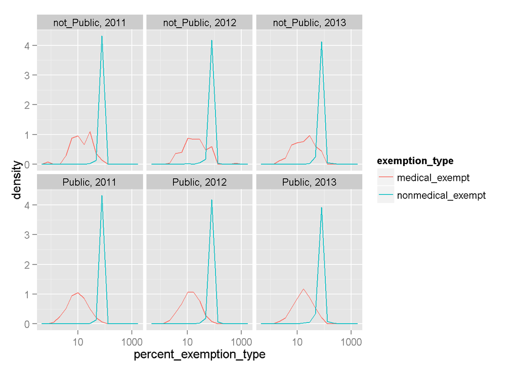

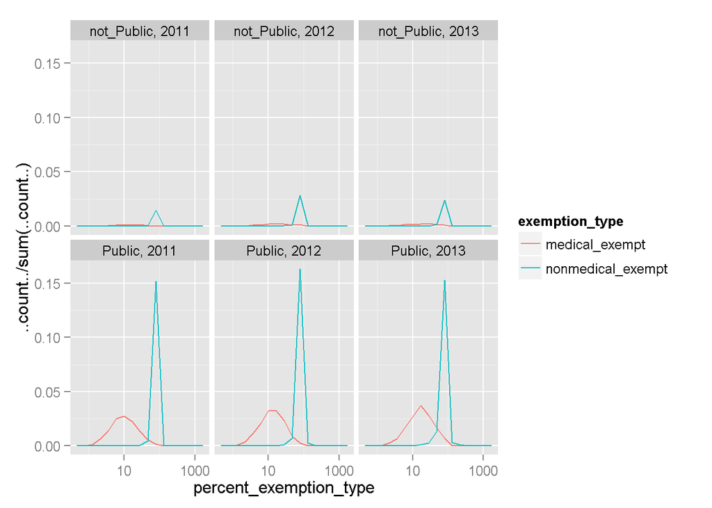

Public and private schools have similiar distributions and rates of both types of exemptions, for all three school years. Public schools have a larger proportion of exempitons of both types.

# Univariate Analysis

### What is/are the main feature(s) of interest in your dataset?

Number of exemptions per school: total, by type (medical and non-medical), and MMR.

### What other features in the dataset do you think will help support your investigation into your feature(s) of interest?

School enrollment and school type.

### Did you create any new variables from existing variables in the dataset?

I created % of each total and each exemption using the number respective to the exemtion and enrollment, for each schools.

### Of the features you investigated, were there any unusual distributions? Did you perform any operations on the data to tidy, adjust, or change the form of the data? If so, why did you do this?

I was suprised to see that two of the smaller counties, Ferry and San Juan had distributions shifted to higher percent of all exemptions than King County. The narrative in the Seattle media led me to believe that the highest exemption rates would be observed in King County and the Seattle area in general. I was also surprised to find the public and private schools have similiar distribuions, albeit different proportions, respective to exemption type. This is the case on a proportion basis, but not for rate. However, the schools in these counties tend to be much smaller so the rates shift dramatically per exempt student. There was substantial tidying of the orignal data sets as per the github links in the introduction. I extracted a subset of the data consisting of only schools that reported exemptions for the three schools years. This elminated ~ 1200 observations but was necessary since non-reporting schools are missing all exemption values and typcially enrollment as well.

# Bivariate Plots Section

## Group by County and School Type

Group observations by county, and by county & school type (public, not public) for the most recent school year, 2013-2014. A data subset was used that includes only schools with enrollment of 10 - 2500 students.

```
##  [1] "school_county"                 "mean_percent_medical_exempt"
##  [3] "median_percent_medical_exempt" "max_percent_medical_exempt"
##  [5] "min_percent_medical_exempt"    "mean_percent_exempt_MMR"
##  [7] "median_percent_exempt_MMR"     "max_percent_exempt_MMR"
##  [9] "min_percent_exempt_MMR"        "mean_percent_exempt"
## [11] "median_percent_exempt"         "max_percent_exempt"
## [13] "min_percent_exempt"            "mean_percent_nonmedexempt"
## [15] "median_percent_nonmedexempt"   "max_percent_nonmedexempt"
## [17] "min_percent_nonmedexempt"      "schools"
## [19] "students"
```

```
##  school_county      mean_percent_medical_exempt
##  Length:39          Min.   :0.0000
##  Class :character   1st Qu.:0.3250
##  Mode  :character   Median :0.5900
##                     Mean   :0.8056
##                     3rd Qu.:1.1700
##                     Max.   :1.9900
##  median_percent_medical_exempt max_percent_medical_exempt
##  Min.   :0.0000                Min.   : 0.000
##  1st Qu.:0.0000                1st Qu.: 1.425
##  Median :0.4000                Median : 4.000
##  Mean   :0.3887                Mean   : 6.151
##  3rd Qu.:0.5750                3rd Qu.: 8.040
##  Max.   :2.1100                Max.   :29.630
##  min_percent_medical_exempt mean_percent_exempt_MMR
##  Min.   :0                  Min.   : 0.880
##  1st Qu.:0                  1st Qu.: 3.025
##  Median :0                  Median : 4.420
##  Mean   :0                  Mean   : 5.170
##  3rd Qu.:0                  3rd Qu.: 6.360
##  Max.   :0                  Max.   :14.680
##  median_percent_exempt_MMR max_percent_exempt_MMR min_percent_exempt_MMR
##  Min.   : 0.730            Min.   : 0.91          Min.   :0.0000
##  1st Qu.: 2.285            1st Qu.:10.42          1st Qu.:0.0000
##  Median : 3.300            Median :22.81          Median :0.0000
##  Mean   : 3.924            Mean   :23.12          Mean   :0.6167
##  3rd Qu.: 4.770            3rd Qu.:33.33          3rd Qu.:0.4000
##  Max.   :11.170            Max.   :64.29          Max.   :7.1400
##  mean_percent_exempt median_percent_exempt max_percent_exempt
##  Min.   : 1.320      Min.   : 1.060        Min.   : 2.13
##  1st Qu.: 4.390      1st Qu.: 3.570        1st Qu.:15.02
##  Median : 7.120      Median : 5.610        Median :30.77
##  Mean   : 7.723      Mean   : 6.429        Mean   :28.47
##  3rd Qu.: 8.695      3rd Qu.: 7.205        3rd Qu.:42.28
##  Max.   :22.830      Max.   :23.080        Max.   :71.43
##  min_percent_exempt mean_percent_nonmedexempt median_percent_nonmedexempt
##  Min.   : 0.000     Min.   : 1.040            Min.   : 0.670
##  1st Qu.: 0.000     1st Qu.: 3.860            1st Qu.: 2.970
##  Median : 0.000     Median : 6.440            Median : 5.020
##  Mean   : 1.415     Mean   : 7.056            Mean   : 5.869
##  3rd Qu.: 1.315     3rd Qu.: 7.730            3rd Qu.: 6.720
##  Max.   :14.000     Max.   :22.180            Max.   :23.080
##  max_percent_nonmedexempt min_percent_nonmedexempt    schools
##  Min.   : 2.13            Min.   : 0.000           Min.   :  1.00
##  1st Qu.:13.77            1st Qu.: 0.000           1st Qu.: 13.00
##  Median :26.56            Median : 0.000           Median : 24.00
##  Mean   :26.81            Mean   : 1.246           Mean   : 58.79
##  3rd Qu.:37.98            3rd Qu.: 1.170           3rd Qu.: 53.50
##  Max.   :71.43            Max.   :12.000           Max.   :581.00
##     students
##  Min.   :    28
##  1st Qu.:  2648
##  Median :  8244
##  Mean   : 27302
##  3rd Qu.: 23350
##  Max.   :289034
```

```
## Classes 'tbl_df', 'tbl' and 'data.frame':    39 obs. of  19 variables:
##  $ school_county                : chr  "KING" "PIERCE" "SNOHOMISH" "CLARK" ...
##  $ mean_percent_medical_exempt  : num  1.99 0.72 1.13 0.59 0.87 0.27 0.96 1.15 0.5 1.2 ...
##  $ median_percent_medical_exempt: num  0.82 0.52 0.68 0.5 0.59 0.16 0.73 0.55 0.21 0.83 ...
##  $ max_percent_medical_exempt   : num  29.63 7.46 12.26 2.3 14.29 ...
##  $ min_percent_medical_exempt   : num  0 0 0 0 0 0 0 0 0 0 ...
##  $ mean_percent_exempt_MMR      : num  3.51 2.96 4.42 5.36 5.5 1.37 5.26 4.67 3.19 6.33 ...
##  $ median_percent_exempt_MMR    : num  2.48 2.23 3.3 4.57 3.57 0.76 3.91 3.55 2.26 4.38 ...
##  $ max_percent_exempt_MMR       : num  36.5 33.1 32.2 36.5 44.9 ...
##  $ min_percent_exempt_MMR       : num  0 0 0 0 0 0 0 0.62 0 0 ...
##  $ mean_percent_exempt          : num  6.77 4.42 6.96 7.27 8.15 2.13 7.55 7.44 4.1 9.69 ...
##  $ median_percent_exempt        : num  5.03 3.66 5.42 6.5 6.03 1.38 5.97 5.95 3.21 7.27 ...
##  $ max_percent_exempt           : num  43.9 33.8 42.7 44 44.3 ...
##  $ min_percent_exempt           : num  0 0 0 0 0 0 0 1.25 0 0 ...
##  $ mean_percent_nonmedexempt    : num  4.99 3.88 5.97 6.84 7.3 1.91 6.7 6.44 3.62 8.58 ...
##  $ median_percent_nonmedexempt  : num  3.6 2.97 4.66 6.14 5.35 1.14 4.88 5.13 2.95 6.55 ...
##  $ max_percent_nonmedexempt     : num  42.9 33.8 37.4 42.7 44.3 ...
##  $ min_percent_nonmedexempt     : num  0 0 0 0 0 0 0 0.42 0 0 ...
##  $ schools                      : int  581 253 205 129 165 90 86 78 57 72 ...
##  $ students                     : num  289034 132412 108104 78252 76901 ...
```

```
## Observations: 39
## Variables:
## $ school_county                 (chr) "KING", "PIERCE", "SNOHOMISH", "...
## $ mean_percent_medical_exempt   (dbl) 1.99, 0.72, 1.13, 0.59, 0.87, 0....
## $ median_percent_medical_exempt (dbl) 0.82, 0.52, 0.68, 0.50, 0.59, 0....
## $ max_percent_medical_exempt    (dbl) 29.63, 7.46, 12.26, 2.30, 14.29,...
## $ min_percent_medical_exempt    (dbl) 0, 0, 0, 0, 0, 0, 0, 0, 0, 0, 0,...
## $ mean_percent_exempt_MMR       (dbl) 3.51, 2.96, 4.42, 5.36, 5.50, 1....
## $ median_percent_exempt_MMR     (dbl) 2.48, 2.23, 3.30, 4.57, 3.57, 0....
## $ max_percent_exempt_MMR        (dbl) 36.50, 33.10, 32.18, 36.48, 44.9...
## $ min_percent_exempt_MMR        (dbl) 0.00, 0.00, 0.00, 0.00, 0.00, 0....
## $ mean_percent_exempt           (dbl) 6.77, 4.42, 6.96, 7.27, 8.15, 2....
## $ median_percent_exempt         (dbl) 5.03, 3.66, 5.42, 6.50, 6.03, 1....
## $ max_percent_exempt            (dbl) 43.87, 33.79, 42.70, 43.97, 44.3...
## $ min_percent_exempt            (dbl) 0.00, 0.00, 0.00, 0.00, 0.00, 0....
## $ mean_percent_nonmedexempt     (dbl) 4.99, 3.88, 5.97, 6.84, 7.30, 1....
## $ median_percent_nonmedexempt   (dbl) 3.60, 2.97, 4.66, 6.14, 5.35, 1....
## $ max_percent_nonmedexempt      (dbl) 42.86, 33.79, 37.44, 42.67, 44.3...
## $ min_percent_nonmedexempt      (dbl) 0.00, 0.00, 0.00, 0.00, 0.00, 0....
## $ schools                       (int) 581, 253, 205, 129, 165, 90, 86,...
## $ students                      (dbl) 289034, 132412, 108104, 78252, 7...
```

```
##  [1] "school_county"                 "school_type"
##  [3] "mean_percent_medical_exempt"   "median_percent_medical_exempt"
##  [5] "max_percent_medical_exempt"    "min_percent_medical_exempt"
##  [7] "mean_percent_exempt_MMR"       "median_percent_exempt_MMR"
##  [9] "max_percent_exempt_MMR"        "min_percent_exempt_MMR"
## [11] "mean_percent_exempt"           "median_percent_exempt"
## [13] "max_percent_exempt"            "min_percent_exempt"
## [15] "mean_percent_nonmedexempt"     "median_percent_nonmedexempt"
## [17] "max_percent_nonmedexempt"      "min_percent_nonmedexempt"
## [19] "schools"                       "students"
```

```
##  school_county          school_type mean_percent_medical_exempt
##  Length:69          not_Public:30   Min.   :0.0000
##  Class :character   Public    :39   1st Qu.:0.1900
##  Mode  :character                   Median :0.6300
##                                     Mean   :0.9884
##                                     3rd Qu.:1.2400
##                                     Max.   :7.1400
##  median_percent_medical_exempt max_percent_medical_exempt
##  Min.   :0.0000                Min.   : 0.00
##  1st Qu.:0.0000                1st Qu.: 1.14
##  Median :0.1600                Median : 2.47
##  Mean   :0.4633                Mean   : 4.76
##  3rd Qu.:0.5800                3rd Qu.: 7.27
##  Max.   :7.1400                Max.   :29.63
##  min_percent_medical_exempt mean_percent_exempt_MMR
##  Min.   :0.0000             Min.   : 0.870
##  1st Qu.:0.0000             1st Qu.: 3.100
##  Median :0.0000             Median : 4.930
##  Mean   :0.1571             Mean   : 7.024
##  3rd Qu.:0.0000             3rd Qu.: 8.230
##  Max.   :7.1400             Max.   :28.570
##  median_percent_exempt_MMR max_percent_exempt_MMR min_percent_exempt_MMR
##  Min.   : 0.610            Min.   : 0.91          Min.   : 0.000
##  1st Qu.: 2.400            1st Qu.: 8.82          1st Qu.: 0.000
##  Median : 3.830            Median :17.39          Median : 0.000
##  Mean   : 6.021            Mean   :19.72          Mean   : 2.618
##  3rd Qu.: 6.630            3rd Qu.:30.77          3rd Qu.: 1.550
##  Max.   :28.570            Max.   :64.29          Max.   :28.570
##  mean_percent_exempt median_percent_exempt max_percent_exempt
##  Min.   : 1.320      Min.   : 0.980        Min.   : 2.13
##  1st Qu.: 5.280      1st Qu.: 4.090        1st Qu.:10.53
##  Median : 7.140      Median : 5.970        Median :23.08
##  Mean   : 9.782      Mean   : 8.779        Mean   :24.25
##  3rd Qu.:11.150      3rd Qu.: 9.900        3rd Qu.:37.50
##  Max.   :35.710      Max.   :35.710        Max.   :71.43
##  min_percent_exempt mean_percent_nonmedexempt median_percent_nonmedexempt
##  Min.   : 0.000     Min.   : 1.040            Min.   : 0.670
##  1st Qu.: 0.000     1st Qu.: 4.450            1st Qu.: 3.510
##  Median : 0.910     Median : 6.720            Median : 5.260
##  Mean   : 3.905     Mean   : 8.932            Mean   : 7.956
##  3rd Qu.: 3.230     3rd Qu.:10.530            3rd Qu.: 9.380
##  Max.   :35.710     Max.   :31.640            Max.   :28.570
##  max_percent_nonmedexempt min_percent_nonmedexempt    schools
##  Min.   : 2.13            Min.   : 0.000           Min.   :  1.00
##  1st Qu.:10.34            1st Qu.: 0.000           1st Qu.:  2.00
##  Median :21.05            Median : 0.450           Median : 13.00
##  Mean   :22.77            Mean   : 3.622           Mean   : 33.23
##  3rd Qu.:36.21            3rd Qu.: 3.180           3rd Qu.: 29.00
##  Max.   :71.43            Max.   :28.570           Max.   :449.00
##     students
##  Min.   :    11
##  1st Qu.:   336
##  Median :  2502
##  Mean   : 15431
##  3rd Qu.:  9944
##  Max.   :260309
```

[output not shown]

[output cut: 14 more lines]

[output not shown]

```
## Observations: 69
## Variables:
## $ school_county                 (chr) "ADAMS", "ASOTIN", "ASOTIN", "BE...
## $ school_type                   (fctr) Public, Public, not_Public, Pub...
## $ mean_percent_medical_exempt   (dbl) 0.22, 2.29, 0.00, 0.36, 1.56, 0....
## $ median_percent_medical_exempt (dbl) 0.19, 2.29, 0.00, 0.22, 0.00, 0....
## $ max_percent_medical_exempt    (dbl) 0.74, 2.47, 0.00, 2.78, 7.27, 1....
## $ min_percent_medical_exempt    (dbl) 0.00, 2.11, 0.00, 0.00, 0.00, 0....
## $ mean_percent_exempt_MMR       (dbl) 3.71, 3.70, 2.97, 2.90, 5.26, 2....
## $ median_percent_exempt_MMR     (dbl) 1.31, 3.70, 2.97, 2.23, 4.00, 1....
## $ max_percent_exempt_MMR        (dbl) 30.77, 5.30, 2.97, 14.70, 12.50,...
## $ min_percent_exempt_MMR        (dbl) 0.22, 2.11, 2.97, 0.00, 0.00, 0....
## $ mean_percent_exempt           (dbl) 5.57, 5.59, 4.95, 3.77, 6.45, 3....
## $ median_percent_exempt         (dbl) 2.03, 5.59, 4.95, 3.19, 7.94, 2....
## $ max_percent_exempt            (dbl) 38.46, 6.36, 4.95, 21.09, 12.50,...
## $ min_percent_exempt            (dbl) 0.87, 4.82, 4.95, 0.00, 0.00, 0....
## $ mean_percent_nonmedexempt     (dbl) 5.36, 3.30, 4.95, 3.44, 4.89, 3....
## $ median_percent_nonmedexempt   (dbl) 1.79, 3.30, 4.95, 2.88, 4.80, 2....
## $ max_percent_nonmedexempt      (dbl) 38.46, 3.89, 4.95, 21.09, 12.50,...
## $ min_percent_nonmedexempt      (dbl) 0.43, 2.71, 4.95, 0.00, 0.00, 0....
## $ schools                       (int) 13, 2, 1, 50, 7, 29, 2, 21, 4, 1...
## $ students                      (dbl) 6040, 615, 101, 33026, 1133, 129...
```

## Total Exemptions vs. Enrollment

```
## geom_smooth: method="auto" and size of largest group is >=1000, so using gam with formula: y ~ s(x, bs = "cs"). Use 'method = x' to change the smoothing method.
```

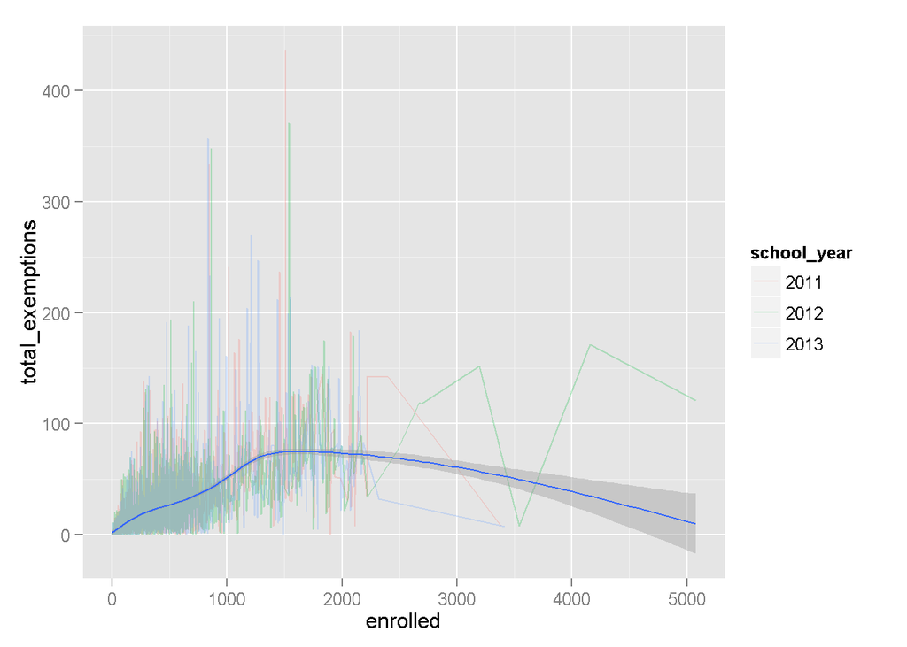

```
## geom_smooth: method="auto" and size of largest group is >=1000, so using gam with formula: y ~ s(x, bs = "cs"). Use 'method = x' to change the smoothing method.
```

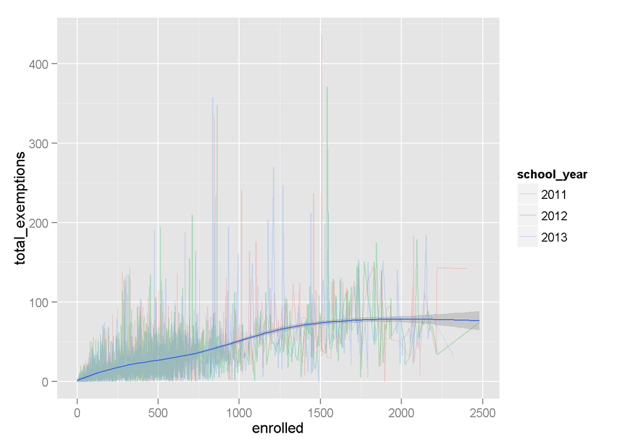

For most of the data (enrollment up to ~1500) there is a linear relationship between total exemptions and number of students enrolled, this isn’t surprising. It would be more intersting to look at the rate, since it is normalized for population.